# ExtraaLearn Project

## Context

The EdTech industry has been surging in the past decade immensely, and according to a forecast, the Online Education market would be worth $286.62bn by 2023 with a compound annual growth rate (CAGR) of 10.26% from 2018 to 2023. The modern era of online education has enforced a lot in its growth and expansion beyond any limit. Due to having many dominant features like ease of information sharing, personalized learning experience, transparency of assessment, etc, it is now preferable to traditional education.

In the present scenario due to the Covid-19, the online education sector has witnessed rapid growth and is attracting a lot of new customers. Due to this rapid growth, many new companies have emerged in this industry. With the availability and ease of use of digital marketing resources, companies can reach out to a wider audience with their offerings. The customers who show interest in these offerings are termed as leads. There are various sources of obtaining leads for Edtech companies, like

- The customer interacts with the marketing front on social media or other online platforms.
- The customer browses the website/app and downloads the brochure
- The customer connects through emails for more information.

The company then nurtures these leads and tries to convert them to paid customers. For this, the representative from the organization connects with the lead on call or through email to share further details.

## Objective

ExtraaLearn is an initial stage startup that offers programs on cutting-edge technologies to students and professionals to help them upskill/reskill. With a large number of leads being generated on a regular basis, one of the issues faced by ExtraaLearn is to identify which of the leads are more likely to convert so that they can allocate resources accordingly. You, as a data scientist at ExtraaLearn, have been provided the leads data to:

- Analyze and build an ML model to help identify which leads are more likely to convert to paid customers,
- Find the factors driving the lead conversion process
- Create a profile of the leads which are likely to convert

## Data Description

The data contains the different attributes of leads and their interaction details with ExtraaLearn. The detailed data dictionary is given below.

**Data Dictionary**

- ID: ID of the lead
- age: Age of the lead
- current_occupation: Current occupation of the lead. Values include 'Professional','Unemployed',and 'Student'
- first_interaction: How did the lead first interacted with ExtraaLearn. Values include 'Website', 'Mobile App'
- profile_completed: What percentage of profile has been filled by the lead on the website/mobile app. Values include Low - (0-50%), Medium - (50-75%), High (75-100%)
- website_visits: How many times has a lead visited the website
- time_spent_on_website: Total time spent on the website
- page_views_per_visit: Average number of pages on the website viewed during the visits.
- last_activity: Last interaction between the lead and ExtraaLearn.
  - Email Activity: Seeking for details about program through email, Representative shared information with lead like brochure of program , etc
  - Phone Activity: Had a Phone Conversation with representative, Had conversation over SMS with representative, etc
  - Website Activity: Interacted on live chat with representative, Updated profile on website, etc
- print_media_type1: Flag indicating whether the lead had seen the ad of ExtraaLearn in the Newspaper.
- print_media_type2: Flag indicating whether the lead had seen the ad of ExtraaLearn in the Magazine.
- digital_media: Flag indicating whether the lead had seen the ad of ExtraaLearn on the digital platforms.
- educational_channels: Flag indicating whether the lead had heard about ExtraaLearn in the education channels like online forums, discussion threads, educational websites, etc.
- referral: Flag indicating whether the lead had heard about ExtraaLearn through reference.
- status: Flag indicating whether the lead was converted to a paid customer or not.

## Importing necessary libraries and data

```python
import pandas as pd

import numpy as np

import matplotlib.pyplot as plt

import seaborn as sns

# To scale the data using z-score
from sklearn.preprocessing import StandardScaler

from sklearn.model_selection import train_test_split

# Algorithms to use
from sklearn import tree

from sklearn.tree import DecisionTreeClassifier

from sklearn.ensemble import RandomForestClassifier

# Metrics to evaluate the model
from sklearn import metrics

from sklearn.metrics import confusion_matrix, classification_report,recall_score,precision_score, accuracy_score

# For tuning the model
from sklearn.model_selection import GridSearchCV

# Setting the random seed to 1 for reproducibility of results
import random
random.seed(1)
np.random.seed(1)

# To ignore warnings
import warnings
warnings.filterwarnings("ignore")
```

## Data Overview

- Observations
- Sanity checks

## **Loading the dataset**

```python
from google.colab import drive
drive.mount('/content/drive')
```

```python
data= pd.read_csv('/content/drive/MyDrive/Data science MIT/Project/ExtraaLearn (1).csv')
```

```python
data.head()
```

|  | ID | age | current_occupation | first_interaction | profile_completed | website_visits | time_spent_on_website | page_views_per_visit | last_activity | print_media_type1 | print_media_type2 | digital_media | educational_channels | referral | status |
| --- | --- | --- | --- | --- | --- | --- | --- | --- | --- | --- | --- | --- | --- | --- | --- |
| 0 | EXT001 | 57 | Unemployed | Website | High | 7 | 1639 | 1.861 | Website Activity | Yes | No | Yes | No | No | 1 |
| 1 | EXT002 | 56 | Professional | Mobile App | Medium | 2 | 83 | 0.320 | Website Activity | No | No | No | Yes | No | 0 |
| 2 | EXT003 | 52 | Professional | Website | Medium | 3 | 330 | 0.074 | Website Activity | No | No | Yes | No | No | 0 |
| 3 | EXT004 | 53 | Unemployed | Website | High | 4 | 464 | 2.057 | Website Activity | No | No | No | No | No | 1 |
| 4 | EXT005 | 23 | Student | Website | High | 4 | 600 | 16.914 | Email Activity | No | No | No | No | No | 0 |

```python
data.tail()
```

|  | ID | age | current_occupation | first_interaction | profile_completed | website_visits | time_spent_on_website | page_views_per_visit | last_activity | print_media_type1 | print_media_type2 | digital_media | educational_channels | referral | status |
| --- | --- | --- | --- | --- | --- | --- | --- | --- | --- | --- | --- | --- | --- | --- | --- |
| 4607 | EXT4608 | 35 | Unemployed | Mobile App | Medium | 15 | 360 | 2.170 | Phone Activity | No | No | No | Yes | No | 0 |
| 4608 | EXT4609 | 55 | Professional | Mobile App | Medium | 8 | 2327 | 5.393 | Email Activity | No | No | No | No | No | 0 |
| 4609 | EXT4610 | 58 | Professional | Website | High | 2 | 212 | 2.692 | Email Activity | No | No | No | No | No | 1 |
| 4610 | EXT4611 | 57 | Professional | Mobile App | Medium | 1 | 154 | 3.879 | Website Activity | Yes | No | No | No | No | 0 |
| 4611 | EXT4612 | 55 | Professional | Website | Medium | 4 | 2290 | 2.075 | Phone Activity | No | No | No | No | No | 0 |

## **Data Overview**

```python
# Let us see the info of the data
data.info()
```

```
<class 'pandas.core.frame.DataFrame'>
RangeIndex: 4612 entries, 0 to 4611
Data columns (total 15 columns):
 #   Column                 Non-Null Count  Dtype
---  ------                 --------------  -----
 0   ID                     4612 non-null   object
 1   age                    4612 non-null   int64
 2   current_occupation     4612 non-null   object
 3   first_interaction      4612 non-null   object
 4   profile_completed      4612 non-null   object
 5   website_visits         4612 non-null   int64
 6   time_spent_on_website  4612 non-null   int64
 7   page_views_per_visit   4612 non-null   float64
 8   last_activity          4612 non-null   object
 9   print_media_type1      4612 non-null   object
 10  print_media_type2      4612 non-null   object
 11  digital_media          4612 non-null   object
 12  educational_channels   4612 non-null   object
 13  referral               4612 non-null   object
 14  status                 4612 non-null   int64
dtypes: float64(1), int64(4), object(10)
memory usage: 540.6+ KB
```

### **Duplicated and Missing Values**

```python
#check for null values
data.isnull().sum()
```

```
ID                       0
age                      0
current_occupation       0
first_interaction        0
profile_completed        0
website_visits           0
time_spent_on_website    0
page_views_per_visit     0
last_activity            0
print_media_type1        0
print_media_type2        0
digital_media            0
educational_channels     0
referral                 0
status                   0
dtype: int64
```

```python
# Let check for missing values
data.duplicated().sum()
```

```
0
```

- It is hence confirmed that there are **no missing values and no duplicate rows** in this dataset

### **Class Distribution**

```python
### Percentage  distribution of the target variable "status"
data['status'].value_counts(1)*100
```

```
0    70.143105
1    29.856895
Name: status, dtype: float64
```

- **More than 70%** of the rows in this dataset belong to status **0**.
- About **30%** of the status are **1**.
- from the above data, we can see that 30% of the leads are likely to convert to paid customers. We can say that more advert needs to be done to convert to get more conversion rate
- This can hence be considered a **somewhat imbalanced** classification problem.

**Let's check the unique values in each column**

```python
# Checking the count of unique values in each column, nunique can give us information on columns that are categorial or numerical
data.nunique()
```

```
ID                       4612
age                        46
current_occupation          3
first_interaction           2
profile_completed           3
website_visits             27
time_spent_on_website    1623
page_views_per_visit     2414
last_activity               3
print_media_type1           2
print_media_type2           2
digital_media               2
educational_channels        2
referral                    2
status                      2
dtype: int64
```

**Observations:**

- **ID is an identifier** which is unique for each customers and **we can drop this column** as it would not add any value to our analysis.
- **we have 10 categorical columns and 5 continous columns.**

**Let's drop the ID columns mentioned above** and define lists for numerical and categorical columns to explore them separately.

```python
# Dropping the columns
data = data.drop(['ID'] , axis = 1)
data.head()
```

|  | age | current_occupation | first_interaction | profile_completed | website_visits | time_spent_on_website | page_views_per_visit | last_activity | print_media_type1 | print_media_type2 | digital_media | educational_channels | referral | status |
| --- | --- | --- | --- | --- | --- | --- | --- | --- | --- | --- | --- | --- | --- | --- |
| 0 | 57 | Unemployed | Website | High | 7 | 1639 | 1.861 | Website Activity | Yes | No | Yes | No | No | 1 |
| 1 | 56 | Professional | Mobile App | Medium | 2 | 83 | 0.320 | Website Activity | No | No | No | Yes | No | 0 |
| 2 | 52 | Professional | Website | Medium | 3 | 330 | 0.074 | Website Activity | No | No | Yes | No | No | 0 |
| 3 | 53 | Unemployed | Website | High | 4 | 464 | 2.057 | Website Activity | No | No | No | No | No | 1 |
| 4 | 23 | Student | Website | High | 4 | 600 | 16.914 | Email Activity | No | No | No | No | No | 0 |

```python
# Get list of numerical columns
num_cols = data.select_dtypes(include=['float64', 'int64']).columns.tolist()

print(num_cols)
```

```
['age', 'website_visits', 'time_spent_on_website', 'page_views_per_visit', 'status']
```

```python
# Get list of categorical columns
cat_cols = data.select_dtypes(include=['object']).columns.tolist()

print(cat_cols)
```

```
['current_occupation', 'first_interaction', 'profile_completed', 'last_activity', 'print_media_type1', 'print_media_type2', 'digital_media', 'educational_channels', 'referral']
```

## Exploratory Data Analysis (EDA)

- EDA is an important part of any project involving data.
- It is important to investigate and understand the data better before building a model with it.
- A few questions have been mentioned below which will help you approach the analysis in the right manner and generate insights from the data.
- A thorough analysis of the data, in addition to the questions mentioned below, should be done.

**Questions**

1. Leads will have different expectations from the outcome of the course and the current occupation may play a key role in getting them to participate in the program. Find out how current occupation affects lead status.
2. The company's first impression on the customer must have an impact. Do the first channels of interaction have an impact on the lead status?
3. The company uses multiple modes to interact with prospects. Which way of interaction works best?
4. The company gets leads from various channels such as print media, digital media, referrals, etc. Which of these channels have the highest lead conversion rate?
5. People browsing the website or mobile application are generally required to create a profile by sharing their personal data before they can access additional information.Does having more details about a prospect increase the chances of conversion?

### **Statistical Summary**

```python
# Let's view the statistical summary of the columns in the dataset
data.describe().T
```

|  | count | mean | std | min | 25% | 50% | 75% | max |
| --- | --- | --- | --- | --- | --- | --- | --- | --- |
| age | 4612.0 | 46.201214 | 13.161454 | 18.0 | 36.00000 | 51.000 | 57.00000 | 63.000 |
| website_visits | 4612.0 | 3.566782 | 2.829134 | 0.0 | 2.00000 | 3.000 | 5.00000 | 30.000 |
| time_spent_on_website | 4612.0 | 724.011275 | 743.828683 | 0.0 | 148.75000 | 376.000 | 1336.75000 | 2537.000 |
| page_views_per_visit | 4612.0 | 3.026126 | 1.968125 | 0.0 | 2.07775 | 2.792 | 3.75625 | 18.434 |
| status | 4612.0 | 0.298569 | 0.457680 | 0.0 | 0.00000 | 0.000 | 1.00000 | 1.000 |

**Observations:**

- The maximum age of the likely customer is 63 and minimum age is 18.
- The mean of website visit is 3.56 times and the maximum visit is 30 whereas the mean and teh maximum of time spent on the website is 724.01 and 2537.
- The mean of the pages views per visit is 3.03 and the maximum page visit is 18.43

### **Unique Values in each Column**

Let's make sure we also understand the number of unique values in each feature of the dataset.

```python
for column in data.columns:
    print(f"Column: {column}")
    print(data[column].value_counts(normalize=True))
    print('-' * 50)
```

```
Column: age
57    0.083478
58    0.082827
56    0.071552
59    0.071119
60    0.051605
55    0.043365
32    0.040763
53    0.019731
24    0.019514
43    0.019297
48    0.019081
51    0.019081
54    0.019081
49    0.018864
21    0.018647
50    0.018430
46    0.018430
23    0.018430
45    0.018213
42    0.017997
19    0.017563
44    0.017563
47    0.017346
52    0.016696
33    0.016479
20    0.016262
34    0.016045
22    0.015395
41    0.015178
18    0.014310
35    0.014310
40    0.013660
37    0.013010
38    0.012576
36    0.012576
39    0.011275
62    0.010408
63    0.010191
30    0.009540
```

[output cut: 105 more lines]

```
Column: educational_channels
No     0.847138
Yes    0.152862
Name: educational_channels, dtype: float64
--------------------------------------------------
Column: referral
No     0.979835
Yes    0.020165
Name: referral, dtype: float64
--------------------------------------------------
Column: status
0    0.701431
1    0.298569
Name: status, dtype: float64
--------------------------------------------------
```

#### **Univariate Analysis of numerical variables**

We will first define a hist_box() function that provides both a boxplot and a histogram in the same visual, with which we can perform univariate analysis on the columns of this dataset.

```python
# Defining the hist_box() function
def hist_box(col):
  f, (ax_box, ax_hist) = plt.subplots(2, sharex=True, gridspec_kw={'height_ratios': (0.15, 0.85)}, figsize=(15,10))
  sns.set(style='darkgrid')
  # Adding a graph in each part
  sns.boxplot(x=data[col], ax=ax_box, showmeans=True)
  sns.distplot(x=data[col], ax=ax_hist)
  ax_hist.axvline(data[col].mean(), color='green', linestyle='--') # Green line corresponds to the mean in the plot
  ax_hist.axvline(data[col].median(), color='orange', linestyle='-') # Orange line corresponds to the median in the plot
  plt.show()
```

```python
num_cols
```

```
['age',
 'website_visits',
 'time_spent_on_website',
 'page_views_per_visit',
 'status']
```

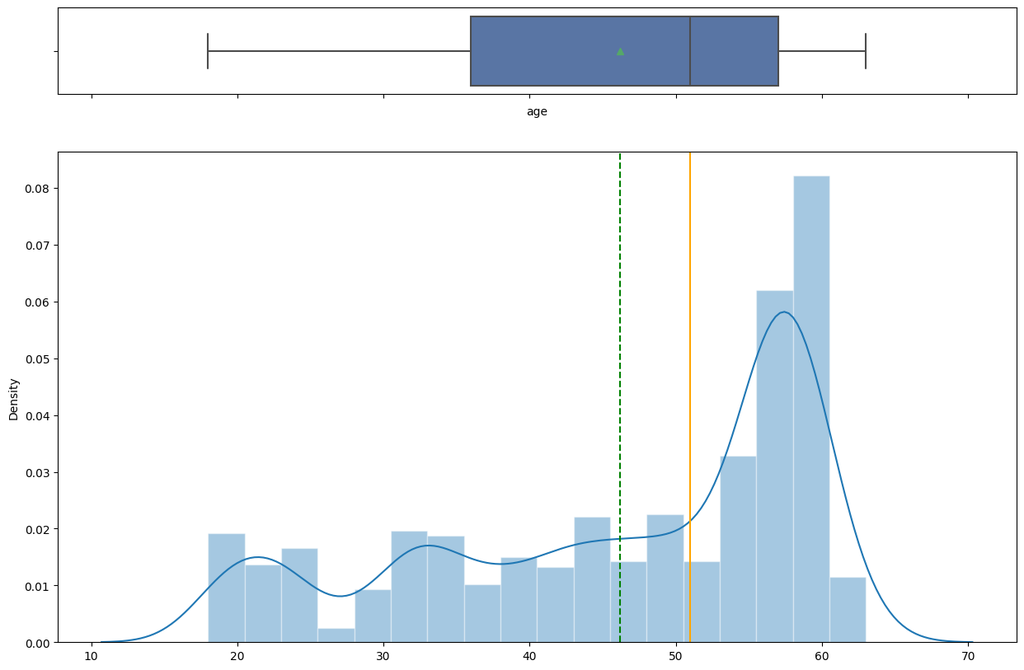

```python
hist_box('age')
```

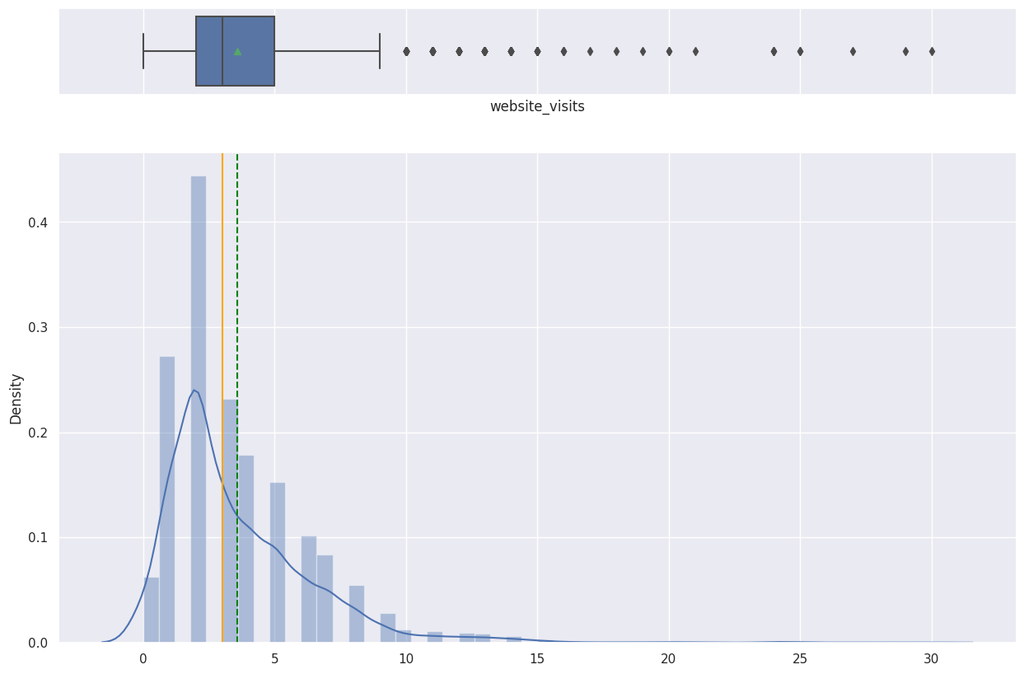

```python
hist_box('website_visits')
```

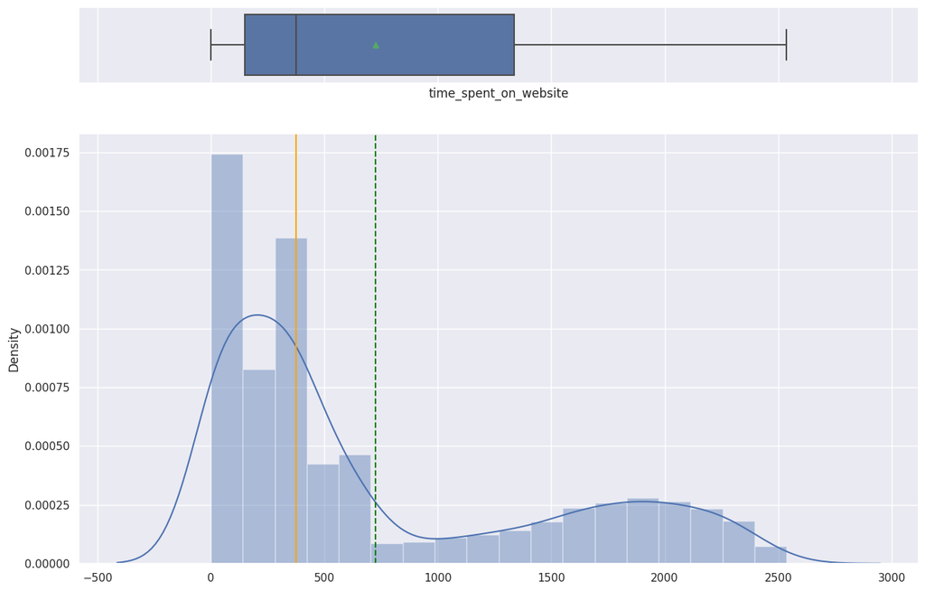

```python
hist_box('time_spent_on_website')
```

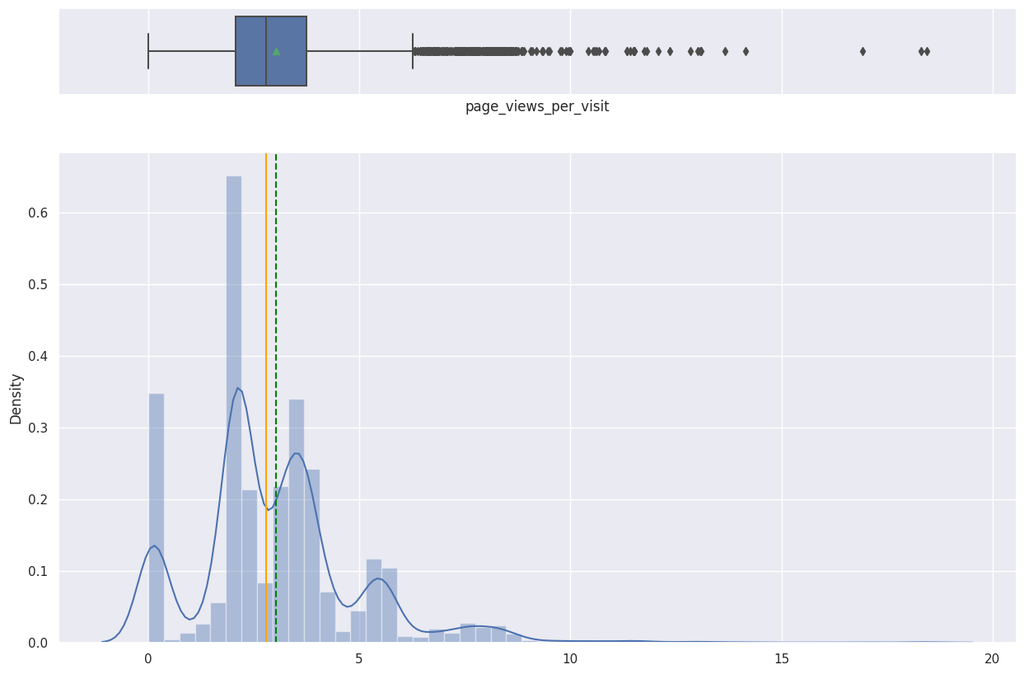

```python
hist_box('page_views_per_visit')
```

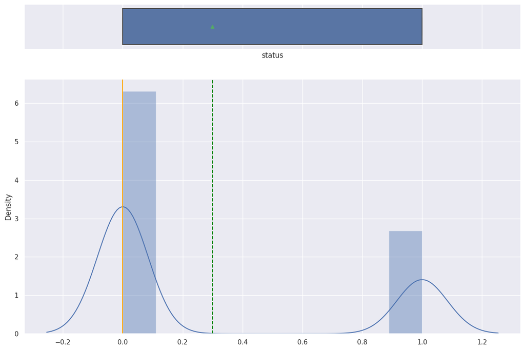

```python
hist_box('status')
```

**Observations:**

- The distribution plot shows that the website_visits, 'time_spent_on_website' , 'page_views_per_visit' are **right-skewed.** It is evident from the boxplots that website_visits and page_views_per_visit variables have outliers.
- The time_spent_on_website variables which do not possess outliers in the boxplot.
- The variables age are **left-skewed** distributions.

#### **Univariate Analysis of categorical variables**

```python
cat_cols
```

```
['current_occupation',
 'first_interaction',
 'profile_completed',
 'last_activity',
 'print_media_type1',
 'print_media_type2',
 'digital_media',
 'educational_channels',
 'referral']
```

```python
# Printing the % sub categories of each category.
for i in cat_cols:

    print(data[i].value_counts(normalize = True))

    print('*' * 40)
```

```
Professional    0.567216
Unemployed      0.312446
Student         0.120338
Name: current_occupation, dtype: float64
Website       0.551171
Mobile App    0.448829
Name: first_interaction, dtype: float64
High      0.490893
Medium    0.485906
Low       0.023200
Name: profile_completed, dtype: float64
Email Activity      0.493929
Phone Activity      0.267563
Website Activity    0.238508
Name: last_activity, dtype: float64
No     0.892238
Yes    0.107762
Name: print_media_type1, dtype: float64
No     0.94948
Yes    0.05052
Name: print_media_type2, dtype: float64
No     0.885733
Yes    0.114267
Name: digital_media, dtype: float64
No     0.847138
Yes    0.152862
Name: educational_channels, dtype: float64
No     0.979835
Yes    0.020165
Name: referral, dtype: float64
```

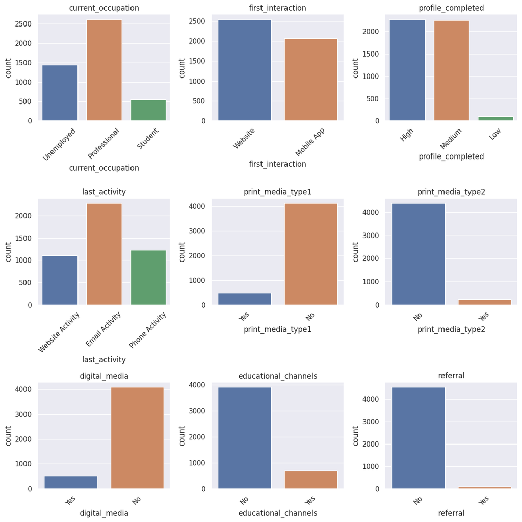

```python
# Create subplots: 3 rows by 2 columns
fig, axes = plt.subplots(nrows=3, ncols=3, figsize=(12, 12))

# The ravel function returns a flattened array
ax = axes.ravel()


for i, col in enumerate(cat_cols):
    sns.countplot(x=col, data=data, ax=ax[i])
    ax[i].set_title(f'{col}')
    ax[i].set_xticklabels(ax[i].get_xticklabels(), rotation=45)

# Adjust layout
plt.tight_layout()
plt.show()
```

### **Bivariate Analysis**

#### **target and dependent variables variables**

```python
num_cols
```

```
['age',
 'website_visits',
 'time_spent_on_website',
 'page_views_per_visit',
 'status']
```

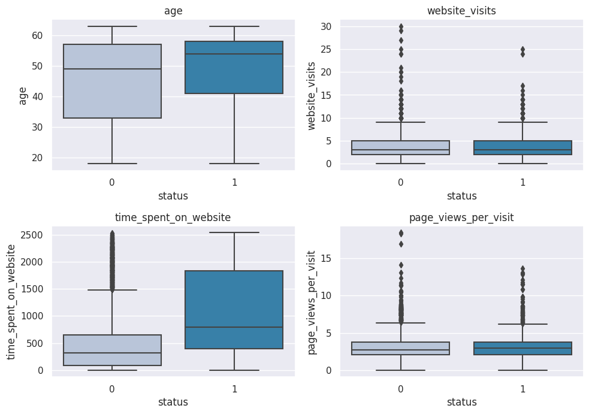

```python
cols = data[['age','website_visits', 'time_spent_on_website','page_views_per_visit',]].columns.tolist()
plt.figure(figsize=(10,10))

for i, variable in enumerate(cols):
                     plt.subplot(3,2,i+1)
                     sns.boxplot(x=data["status"],y=data[variable],palette="PuBu")
                     plt.tight_layout()
                     plt.title(variable)
plt.show()
```

### **Observations:**

- **From the above graph, we see that the time spent on the website had effect on the conversion rate. The higher the time spent on the website the higher the likelihood of conversion to paid customer.**
- **similar pattern was seen with age. A class of older customers are likely to lead to conversion than a class of younger customers.**
- The website visit and the page views per visit had no effect on the conversion rate.

```python
cat_cols
```

```
['current_occupation',
 'first_interaction',
 'profile_completed',
 'last_activity',
 'print_media_type1',
 'print_media_type2',
 'digital_media',
 'educational_channels',
 'referral']
```

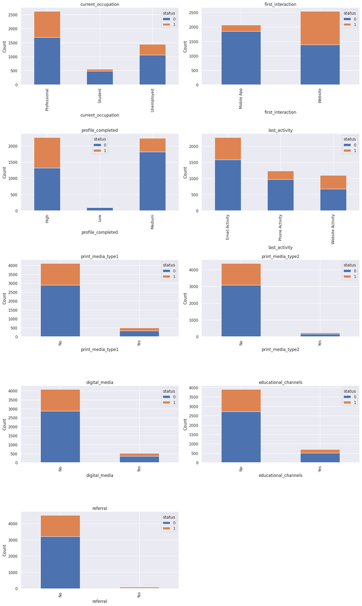

```python
cols = data[['current_occupation', 'first_interaction', 'profile_completed', 'last_activity', 'print_media_type1', 'print_media_type2', 'digital_media', 'educational_channels', 'referral']].columns.tolist()

plt.figure(figsize=(15, 25))

for i, variable in enumerate(cols):
    # Crosstab to get the frequency for each category and status
    ct = pd.crosstab(data[variable], data['status'])

    # Plotting the stacked bar chart
    ax = plt.subplot(5, 2, i+1)
    ct.plot(kind="bar", stacked=True, ax=ax)
    plt.title(variable)
    plt.ylabel('Count')
    plt.xticks(rotation=90)
    plt.tight_layout()

plt.show()
```

```python
#lets create a pivot table to show the summary of the data
pivot_table = pd.pivot_table(data, index=['first_interaction', 'last_activity'], columns='status')
pivot_table
```

| first_interaction | status last_activity | age 0 | age 1 | page_views_per_visit 0 | page_views_per_visit 1 | time_spent_on_website 0 | time_spent_on_website 1 | website_visits 0 | website_visits 1 |
| --- | --- | --- | --- | --- | --- | --- | --- | --- | --- |
| Mobile App | Email Activity | 46.378902 | 44.820225 | 2.902839 | 2.985438 | 649.250807 | 1286.011236 | 3.632939 | 3.988764 |
|  | Phone Activity | 45.900574 | 48.861111 | 3.173897 | 2.976194 | 720.066922 | 1531.305556 | 3.818356 | 4.166667 |
|  | Website Activity | 45.777500 | 48.677419 | 3.200897 | 3.165742 | 559.017500 | 1265.774194 | 3.752500 | 3.526882 |
| Website | Email Activity | 44.387538 | 48.940199 | 2.932070 | 3.008875 | 417.714286 | 1065.460133 | 3.310030 | 3.558140 |
|  | Phone Activity | 43.738839 | 49.427313 | 3.001016 | 3.097850 | 613.225446 | 852.511013 | 3.424107 | 3.224670 |
|  | Website Activity | 42.833935 | 48.645455 | 3.167661 | 2.989188 | 415.231047 | 1057.448485 | 3.584838 | 3.530303 |

```python
pivot_table = pd.pivot_table(data,'website_visits', index=['first_interaction', 'last_activity'], columns='status')
pivot_table
```

| first_interaction | status last_activity | 0 | 1 |
| --- | --- | --- | --- |
| Mobile App | Email Activity | 3.632939 | 3.988764 |
|  | Phone Activity | 3.818356 | 4.166667 |
|  | Website Activity | 3.752500 | 3.526882 |
| Website | Email Activity | 3.310030 | 3.558140 |
|  | Phone Activity | 3.424107 | 3.224670 |
|  | Website Activity | 3.584838 | 3.530303 |

[figure not shown]

```python
import seaborn as sns
import matplotlib.pyplot as plt

# Plotting the heatmap
plt.figure(figsize=(12, 8))  # You can adjust the size as needed
sns.heatmap(pivot_table, annot=True, cmap='YlGnBu', fmt='g', cbar_kws={'label': 'Average Age'})
plt.title('Websit visit by First Interaction and Last Activity')
plt.show()
```

**Observation**

- The average website visit from the first interaction to the last interaction had no much impact on the number leads converted to paid customers

```python
pivot_table = pd.pivot_table(data,'time_spent_on_website', index=['first_interaction', 'last_activity'], columns='status')
pivot_table
```

| first_interaction | status last_activity | 0 | 1 |
| --- | --- | --- | --- |
| Mobile App | Email Activity | 649.250807 | 1286.011236 |
|  | Phone Activity | 720.066922 | 1531.305556 |
|  | Website Activity | 559.017500 | 1265.774194 |
| Website | Email Activity | 417.714286 | 1065.460133 |
|  | Phone Activity | 613.225446 | 852.511013 |
|  | Website Activity | 415.231047 | 1057.448485 |

[figure not shown]

```python
#plot the pivot table
import seaborn as sns
import matplotlib.pyplot as plt

# Plotting the heatmap
plt.figure(figsize=(12, 8))  # You can adjust the size as needed
sns.heatmap(pivot_table, annot=True, cmap='YlGnBu', fmt='g', cbar_kws={'label': 'Average Age'})
plt.title('Time spent on website by First Interaction and Last Activity')
plt.show()
```

**Observation**

- customers that spent more time on the website generated more leads

```python
pivot_table = pd.pivot_table(data,'page_views_per_visit', index=['first_interaction', 'last_activity'], columns='status')
pivot_table
```

| first_interaction | status last_activity | 0 | 1 |
| --- | --- | --- | --- |
| Mobile App | Email Activity | 2.902839 | 2.985438 |
|  | Phone Activity | 3.173897 | 2.976194 |
|  | Website Activity | 3.200897 | 3.165742 |
| Website | Email Activity | 2.932070 | 3.008875 |
|  | Phone Activity | 3.001016 | 3.097850 |
|  | Website Activity | 3.167661 | 2.989188 |

[figure not shown]

```python
#plot the pivot table
import seaborn as sns
import matplotlib.pyplot as plt

# Plotting the heatmap
plt.figure(figsize=(12, 8))  # You can adjust the size as needed
sns.heatmap(pivot_table, annot=True, cmap='YlGnBu', fmt='g', cbar_kws={'label': 'Average Age'})
plt.title('Average Page views per visit by First Interaction and Last Activity')
plt.show()
```

**Observation**

- The average page views per visit from the first interaction to the last interaction had no much impact on the number lead generated

```python
pivot_table = pd.pivot_table(data,'age', index=['first_interaction', 'last_activity'], columns='status')
pivot_table
```

| first_interaction | status last_activity | 0 | 1 |
| --- | --- | --- | --- |
| Mobile App | Email Activity | 46.378902 | 44.820225 |
|  | Phone Activity | 45.900574 | 48.861111 |
|  | Website Activity | 45.777500 | 48.677419 |
| Website | Email Activity | 44.387538 | 48.940199 |
|  | Phone Activity | 43.738839 | 49.427313 |
|  | Website Activity | 42.833935 | 48.645455 |

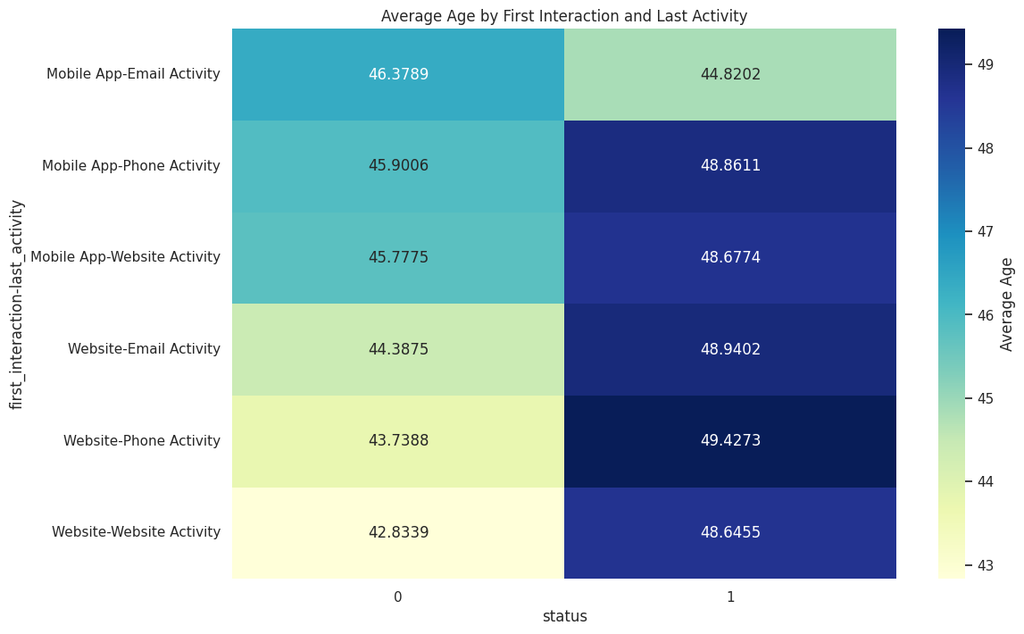

```python
#plot the pivot table
import seaborn as sns
import matplotlib.pyplot as plt

# Plotting the heatmap
plt.figure(figsize=(12, 8))  # You can adjust the size as needed
sns.heatmap(pivot_table, annot=True, cmap='YlGnBu', fmt='g', cbar_kws={'label': 'Average Age'})
plt.title('Average Age by First Interaction and Last Activity')
plt.show()
```

**Observation**

- its seems older customers generated more paid customers. The average age of customers leads that was converted to paid customers were in their late forties.

## Data Preprocessing

- Missing value treatment (if needed)
- Feature engineering (if needed)
- Outlier detection and treatment (if needed)
- Preparing data for modeling
- Any other preprocessing steps (if needed)

```python
data.isnull().sum()
```

```
age                      0
current_occupation       0
first_interaction        0
profile_completed        0
website_visits           0
time_spent_on_website    0
page_views_per_visit     0
last_activity            0
print_media_type1        0
print_media_type2        0
digital_media            0
educational_channels     0
referral                 0
status                   0
dtype: int64
```

**Observation**

- No missing values

**Outliers present in data together**

- Decision trees decide on splits based on the feature values. An outlier can potentially lead to a split that might not be present if the outlier were removed. This means that a small change in data can cause a large change in the structure of the optimal decision tree. If the outlier is noise (an incorrect value), it could lead to overfitting

```python
num_cols
```

```
['age',
 'website_visits',
 'time_spent_on_website',
 'page_views_per_visit',
 'status']
```

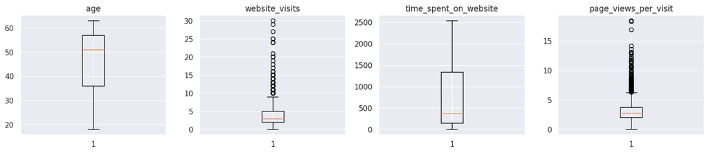

```python
# outlier detection using boxplot
# selecting the numerical columns of data and adding their names in a list
num_cols = ['age','website_visits','time_spent_on_website','page_views_per_visit']

plt.figure(figsize=(15, 12))

for i, variable in enumerate(num_cols):
    plt.subplot(4, 4, i + 1)
    plt.boxplot(data[variable], whis=1.5)
    plt.tight_layout()
    plt.title(variable)

plt.show()
```

```python
# to find the 25th percentile and 75th percentile for the numerical columns.
Q1 = data[num_cols].quantile(0.25)
Q3 = data[num_cols].quantile(0.75)

IQR = Q3 - Q1                   #Inter Quantile Range (75th percentile - 25th percentile)

lower_whisker = Q1 - 1.5*IQR    #Finding lower and upper bounds for all values. All values outside these bounds are outliers
upper_whisker = Q3 + 1.5*IQR
```

```python
# Percentage of outliers in each column
((data[num_cols] < lower_whisker) | (data[num_cols] > upper_whisker)).sum()/data.shape[0]*100
```

```
age                      0.000000
website_visits           3.339115
time_spent_on_website    0.000000
page_views_per_visit     5.572420
dtype: float64
```

**Treating outliers**

We will cap/clip the minimum and maximum value of these columns to the lower and upper whisker value of the boxplot found using **Q1 - 1.5*IQR** and **Q3 + 1.5*IQR**, respectively.

**Note**: Generally, a value of 1.5 * IQR is taken to cap the values of outliers to upper and lower whiskers but any number (example 0.5, 2, 3, etc) other than 1.5 can be chosen. The value depends upon the business problem statement.

**Creating a function to floor and cap/clip outliers in a column**

```python
def treat_outliers(df, col):
    """
    treats outliers in a variable
    col: str, name of the numerical variable
    df: dataframe
    col: name of the column
    """
    Q1 = df[col].quantile(0.25)  # 25th quantile
    Q3 = df[col].quantile(0.75)  # 75th quantile
    IQR = Q3 - Q1                # Inter Quantile Range (75th perentile - 25th percentile)
    lower_whisker = Q1 - 1.5 * IQR
    upper_whisker = Q3 + 1.5 * IQR

    # all the values smaller than lower_whisker will be assigned the value of lower_whisker
    # all the values greater than upper_whisker will be assigned the value of upper_whisker
    # the assignment will be done by using the clip function of NumPy
    df[col] = np.clip(df[col], lower_whisker, upper_whisker)

    return df
```

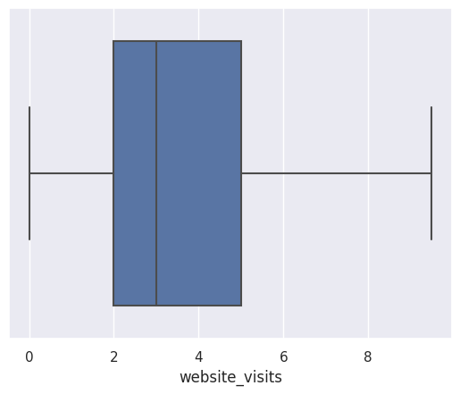

```python
data = treat_outliers(data,'website_visits')

# visualizing the column after outlier treatment
sns.boxplot(data=data,x='website_visits')
plt.show()
```

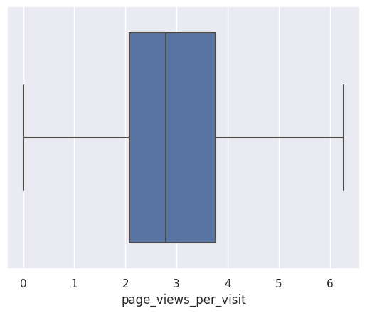

```python
data = treat_outliers(data,'page_views_per_visit')

# visualizing the column after outlier treatment
sns.boxplot(data=data,x='page_views_per_visit')
plt.show()
```

**Let's visualize numerical columns where outliers were treated**

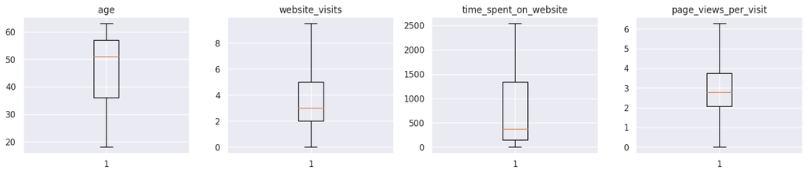

```python
# selecting the numerical columns of data and adding their names in a list
num_cols = ['age','website_visits','time_spent_on_website','page_views_per_visit']

plt.figure(figsize=(15, 12))

for i, variable in enumerate(num_cols):
    plt.subplot(4, 4, i + 1)
    plt.boxplot(data[variable], whis=1.5)
    plt.tight_layout()
    plt.title(variable)

plt.show()
```

- All the outliers have been treated.

**Feature engineering**

**Creating dummy variables for the categorical variables**

```python
cat_cols
```

```
['current_occupation',
 'first_interaction',
 'profile_completed',
 'last_activity',
 'print_media_type1',
 'print_media_type2',
 'digital_media',
 'educational_channels',
 'referral']
```

```python
# Creating a list of columns for which we will create dummy variables
to_get_dummies_for = ['current_occupation', 'first_interaction', 'profile_completed', 'last_activity', 'print_media_type1', 'print_media_type2', 'digital_media','educational_channels','referral']

# Creating dummy variables
df = pd.get_dummies(data = data, columns = to_get_dummies_for, drop_first = True)
```

```python
df
```

|  | age | website_visits | time_spent_on_website | page_views_per_visit | status | current_occupation_Student | current_occupation_Unemployed | first_interaction_Website | profile_completed_Low | profile_completed_Medium | last_activity_Phone Activity | last_activity_Website Activity | print_media_type1_Yes | print_media_type2_Yes | digital_media_Yes | educational_channels_Yes | referral_Yes |
| --- | --- | --- | --- | --- | --- | --- | --- | --- | --- | --- | --- | --- | --- | --- | --- | --- | --- |
| 0 | 57 | 7.0 | 1639 | 1.861 | 1 | 0 | 1 | 1 | 0 | 0 | 0 | 1 | 1 | 0 | 1 | 0 | 0 |
| 1 | 56 | 2.0 | 83 | 0.320 | 0 | 0 | 0 | 0 | 0 | 1 | 0 | 1 | 0 | 0 | 0 | 1 | 0 |
| 2 | 52 | 3.0 | 330 | 0.074 | 0 | 0 | 0 | 1 | 0 | 1 | 0 | 1 | 0 | 0 | 1 | 0 | 0 |
| 3 | 53 | 4.0 | 464 | 2.057 | 1 | 0 | 1 | 1 | 0 | 0 | 0 | 1 | 0 | 0 | 0 | 0 | 0 |
| 4 | 23 | 4.0 | 600 | 6.274 | 0 | 1 | 0 | 1 | 0 | 0 | 0 | 0 | 0 | 0 | 0 | 0 | 0 |
| ... | ... | ... | ... | ... | ... | ... | ... | ... | ... | ... | ... | ... | ... | ... | ... | ... | ... |
| 4607 | 35 | 9.5 | 360 | 2.170 | 0 | 0 | 1 | 0 | 0 | 1 | 1 | 0 | 0 | 0 | 0 | 1 | 0 |
| 4608 | 55 | 8.0 | 2327 | 5.393 | 0 | 0 | 0 | 0 | 0 | 1 | 0 | 0 | 0 | 0 | 0 | 0 | 0 |
| 4609 | 58 | 2.0 | 212 | 2.692 | 1 | 0 | 0 | 1 | 0 | 0 | 0 | 0 | 0 | 0 | 0 | 0 | 0 |
| 4610 | 57 | 1.0 | 154 | 3.879 | 0 | 0 | 0 | 0 | 0 | 1 | 0 | 1 | 1 | 0 | 0 | 0 | 0 |
| 4611 | 55 | 4.0 | 2290 | 2.075 | 0 | 0 | 0 | 1 | 0 | 1 | 1 | 0 | 0 | 0 | 0 | 0 | 0 |

4612 rows × 17 columns

**Preparing data for modeling** Any other preprocessing steps (if needed)

**Separating the independent variables (X) and the dependent variable (Y)**

```python
# Separating independent variables and the target variable
x = df.drop('status',axis=1)

y = df['status']
```

**Splitting the data into 70% train and 30% test set**

```python
# Splitting the data
x_train, x_test, y_train, y_test = train_test_split(x, y, test_size = 0.3, random_state = 1, stratify = y)
```

```python
# Checking the shape of the Train and Test sets
print('X Train Shape:', x_train.shape);
print('X Test Shape:', x_test.shape);
print('Y Train Shape:', y_train.shape);
print('Y Test Shape:', y_test.shape);
```

```
X Train Shape: (3228, 16)
X Test Shape: (1384, 16)
Y Train Shape: (3228,)
Y Test Shape: (1384,)
```

#### **Model evaluation criterion**

```python
# Creating metric function

def metrics_score(actual, predicted):

    print(classification_report(actual, predicted))

    cm = confusion_matrix(actual, predicted)

    plt.figure(figsize = (8, 5))

    sns.heatmap(cm, annot = True, fmt = '.2f', xticklabels = ['0', '1'], yticklabels = ['0', '1'])
    plt.ylabel('Actual')

    plt.xlabel('Predicted')

    plt.show()
```

```python
def model_performance_classification(model, predictors, target):
    """
    Function to compute different metrics to check classification model performance

    model: classifier

    predictors: independent variables

    target: dependent variable
    """

    # Predicting using the independent variables
    pred = model.predict(predictors)

    recall = recall_score(target, pred,average = 'macro')                 # To compute recall

    precision = precision_score(target, pred, average = 'macro')              # To compute precision

    acc = accuracy_score(target, pred)                                 # To compute accuracy score


    # Creating a dataframe of metrics

    df_perf = pd.DataFrame(
        {
            "Precision":  precision,
            "Recall":  recall,
            "Accuracy": acc,
        },

        index = [0],
    )

    return df_perf
```

## Building a Decision Tree model

```python
# Building decision tree model
dt = DecisionTreeClassifier(random_state = 1)
```

```python
# Fitting decision tree model
dt.fit(x_train, y_train)
```

```
DecisionTreeClassifier(random_state=1)
```

**Let's check the model performance of decision tree**

```
              precision    recall  f1-score   support

           0       1.00      1.00      1.00      2264
           1       1.00      1.00      1.00       964

    accuracy                           1.00      3228
   macro avg       1.00      1.00      1.00      3228
weighted avg       1.00      1.00      1.00      3228
```

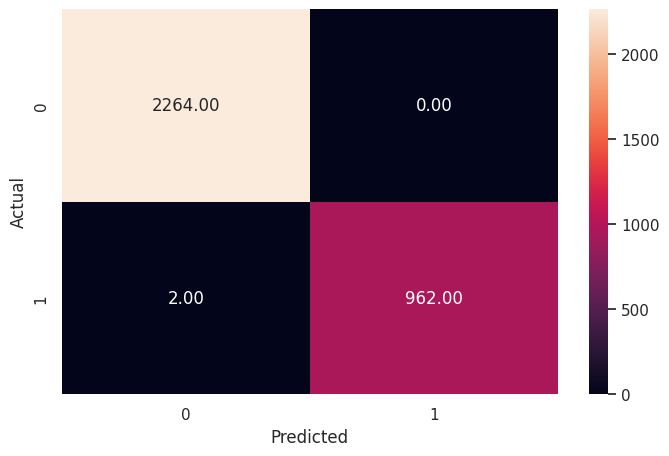

```python
# Checking performance on the training dataset
y_train_pred_dt = dt.predict(x_train)

metrics_score(y_train, y_train_pred_dt)
```

**Observation:**

- The Decision tree is giving a **100% score for all metrics on the training dataset.**

## Model performance evaluation and improvement

```
              precision    recall  f1-score   support

           0       0.85      0.86      0.85       971
           1       0.66      0.66      0.66       413

    accuracy                           0.80      1384
   macro avg       0.76      0.76      0.76      1384
weighted avg       0.80      0.80      0.80      1384
```

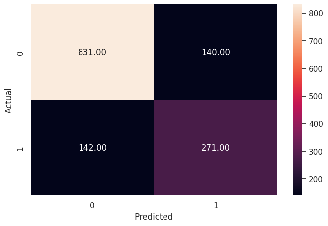

```python
# Checking performance on the test dataset
y_test_pred_dt = dt.predict(x_test)

metrics_score(y_test, y_test_pred_dt)
```

```python
dtree_test = model_performance_classification(dt,x_test,y_test)
dtree_test
```

|  | Precision | Recall | Accuracy |
| --- | --- | --- | --- |
| 0 | 0.756714 | 0.755997 | 0.796243 |

**Observations:**

**Let's plot the feature importance and check the most important features.**

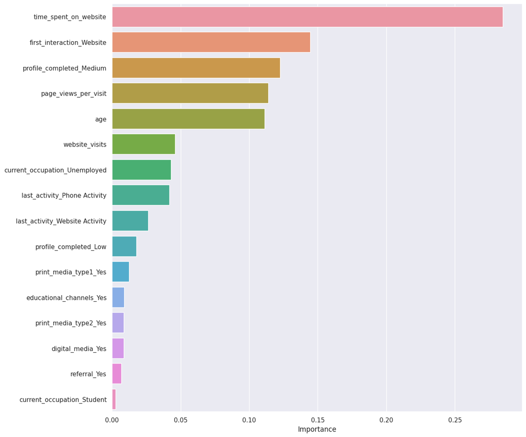

```python
# Plot the feature importance

importances = dt.feature_importances_

columns = x.columns

importance_df = pd.DataFrame(importances, index = columns, columns = ['Importance']).sort_values(by = 'Importance', ascending = False)

plt.figure(figsize = (13, 13))

#sns.barplot(importance_df.Importance,importance_df.index)
sns.barplot(x=importance_df.Importance, y=importance_df.index)
```

**Observation

- The **time spent on the website** is the most important variable with a high significance when compared to other variables.Other important features includes, **first website interaction**, **profile completed medium**, **page views per visit** and **Age**
- **let's add weight to the decision tree model and tune the model to see if there would be any improvement**

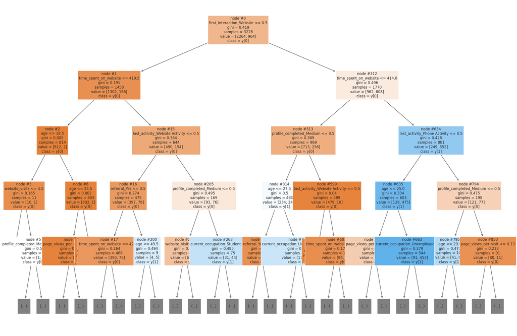

```python
features = list(x.columns)

plt.figure(figsize = (30, 20))

tree.plot_tree(dt, max_depth = 4, feature_names = features, filled = True, fontsize = 12, node_ids = True, class_names = True)

plt.show()
```

### **Note:**

Blue leaves represent the leads, i.e., **y[1]** and the orange leaves represent the non-leads, i.e., **y[0]**. Also, the more the number of observations in a leaf, the darker its color gets.

### **Tuning Models**

```python
# check if there is imbalance in the target variable
data['status'].value_counts(1)
```

```
0    0.701431
1    0.298569
Name: status, dtype: float64
```

**there is imbalance in the target variable**

- to balance it, we would add class weight of 0.30 to class 0 and 0.70 t0 class

```python
# Choose the type of classifier
dtree_estimator = DecisionTreeClassifier(class_weight = {0: 0.30, 1: 0.70}, random_state = 1)

# Grid of parameters to choose from
parameters = {'max_depth': np.arange(2, 8),
              'criterion': ['gini', 'entropy'],
              'min_samples_leaf': [5, 10, 20, 25]
             }

# Type of scoring used to compare parameter combinations
scorer = metrics.make_scorer(recall_score, pos_label = 1)

# Run the grid search
gridCV = GridSearchCV(dtree_estimator, parameters, scoring = scorer, cv = 10)

# Fitting the grid search on the train data
gridCV = gridCV.fit(x_train, y_train)

# Set the classifier to the best combination of parameters
dtree_estimator = gridCV.best_estimator_

# Fit the best estimator to the data
dtree_estimator.fit(x_train, y_train)
```

```
DecisionTreeClassifier(class_weight={0: 0.3, 1: 0.7}, max_depth=3,
                       min_samples_leaf=5, random_state=1)
```

```
              precision    recall  f1-score   support

           0       0.95      0.75      0.84      2264
           1       0.60      0.91      0.72       964

    accuracy                           0.79      3228
   macro avg       0.78      0.83      0.78      3228
weighted avg       0.85      0.79      0.80      3228
```

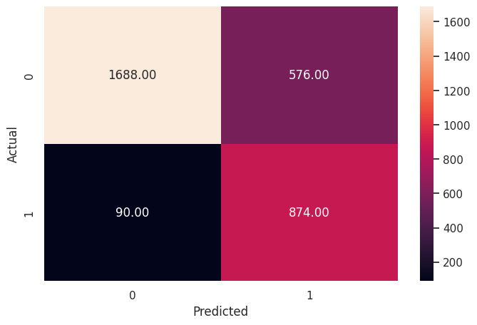

```python
# Checking performance on the training dataset
y_train_pred_dt = dtree_estimator.predict(x_train)

metrics_score(y_train, y_train_pred_dt)
```

**Observation:**

- In comparison to the model with default values of hyperparameters, **the performance on the training set has gone down significantly.** This makes sense because we are trying to reduce overfitting.

```
              precision    recall  f1-score   support

           0       0.94      0.73      0.82       971
           1       0.58      0.89      0.70       413

    accuracy                           0.78      1384
   macro avg       0.76      0.81      0.76      1384
weighted avg       0.83      0.78      0.79      1384
```

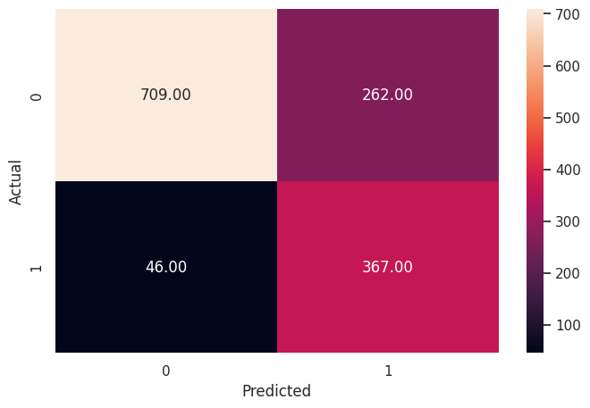

```python
# Checking performance on the test dataset
y_test_pred_dt = dtree_estimator.predict(x_test)

metrics_score(y_test, y_test_pred_dt)
```

```python
dtree_tuned_test = model_performance_classification(dtree_estimator,x_test,y_test)
dtree_tuned_test
```

|  | Precision | Recall | Accuracy |
| --- | --- | --- | --- |
| 0 | 0.761269 | 0.809397 | 0.777457 |

**Observations:**

- The tuned model is performing well in comparison to the model with default values of hyperparameters.
- This model is not overfitting the training data and giving approximately the same result on the test and train datasets.

**Let's look at the feature importance of this model**

**Let's plot the feature importance and check the most important features.**

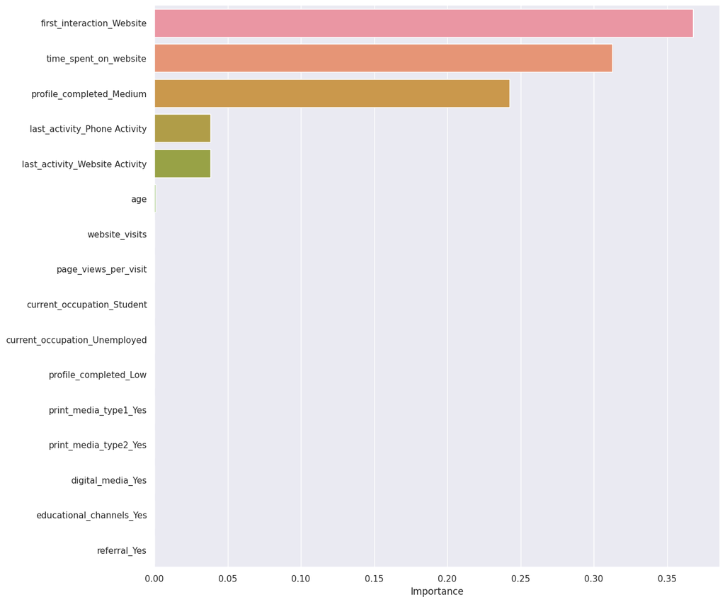

```python
importances = dtree_estimator.feature_importances_

columns = x.columns

importance_df = pd.DataFrame(importances, index = columns, columns = ['Importance']).sort_values(by = 'Importance', ascending = False)

plt.figure(figsize = (13, 13))

sns.barplot(x=importance_df.Importance, y=importance_df.index);
```

**Observations:**

- After tuning the model **first interaction website** became the most important variable. This is different from the previous model where **time spent on website** was the most important variable.
- According to this model, `first interaction` , `time spent on website`, and `profile completed medium` are the 3 most important features that describe important features that could lead to higher paid customers, which might imply that Extralearn should focus more on these features to generate more paid customers.
- Also this model gave a fewer features when compared to the default decision tree model. Its possible that the model is having **high bias**

**Let's plot the tree** and check if the assumptions about first interaction website is true.

As we know the decision tree keeps growing until the nodes are homogeneous, i.e., it has only one class, and the dataset here has a lot of features, it would be hard to visualize the whole tree with so many features. Therefore, we are only visualizing the tree up to **max_depth = 4**.

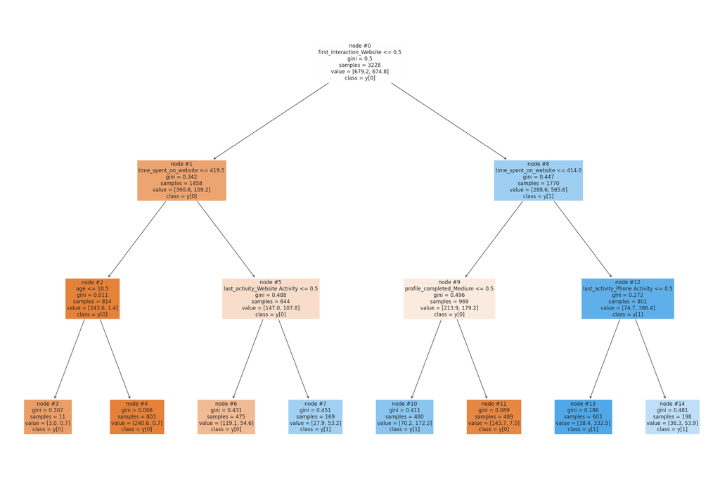

```python
features = list(x.columns)

plt.figure(figsize = (30, 20))

tree.plot_tree(dtree_estimator, max_depth = 4, feature_names = features, filled = True, fontsize = 12, node_ids = True, class_names = True)

plt.show()
```

### **Note:**

Blue leaves represent the leads, i.e., **y[1]** and the orange leaves represent the non-leads, i.e., **y[0]**. Also, the more the number of observations in a leaf, the darker its color gets.

## Building a Random Forest model

**Random Forest is a bagging algorithm where the base models are Decision Trees.** Samples are taken from the training data and on each sample, a decision tree makes a prediction.

```python
# Fitting the Random Forest classifier on the training data
rf_estimator = RandomForestClassifier( random_state = 1)

rf_estimator.fit(x_train, y_train)
```

```
RandomForestClassifier(random_state=1)
```

```
              precision    recall  f1-score   support

           0       1.00      1.00      1.00      2264
           1       1.00      1.00      1.00       964

    accuracy                           1.00      3228
   macro avg       1.00      1.00      1.00      3228
weighted avg       1.00      1.00      1.00      3228
```

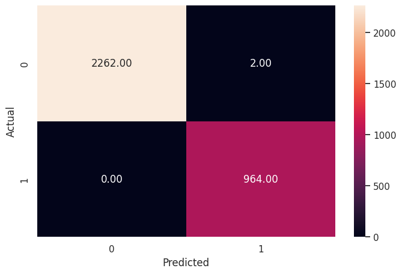

```python
# Checking performance on the training data
y_pred_train_rf = rf_estimator.predict(x_train)

metrics_score(y_train, y_pred_train_rf)
```

**Observation:**

- The Random Forest is giving a **100% score for all metrics on the training dataset.**

## Model Performance evaluation and improvement

```
              precision    recall  f1-score   support

           0       0.89      0.91      0.90       971
           1       0.78      0.72      0.75       413

    accuracy                           0.86      1384
   macro avg       0.83      0.82      0.83      1384
weighted avg       0.86      0.86      0.86      1384
```

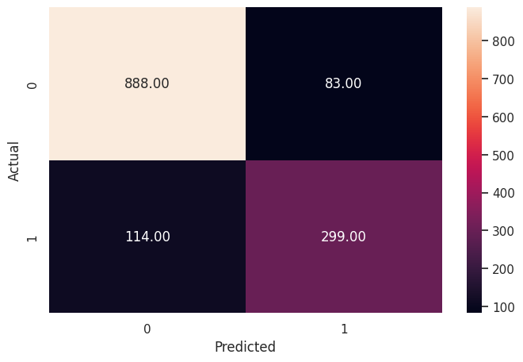

```python
# Checking performance on the testing data
y_pred_test_rf = rf_estimator.predict(x_test)

metrics_score(y_test, y_pred_test_rf)
```

```python
rf_estimator_test = model_performance_classification(rf_estimator,x_test,y_test)
rf_estimator_test
```

|  | Precision | Recall | Accuracy |
| --- | --- | --- | --- |
| 0 | 0.834475 | 0.819246 | 0.857659 |

**Observations:**

- The Random Forest classifier **seems to be overfitting the training data**. The recall on the training data is 1, while the recall on the test data is only ~ 0.70 for class 1.

**Let's check the feature importance of the Random Forest**

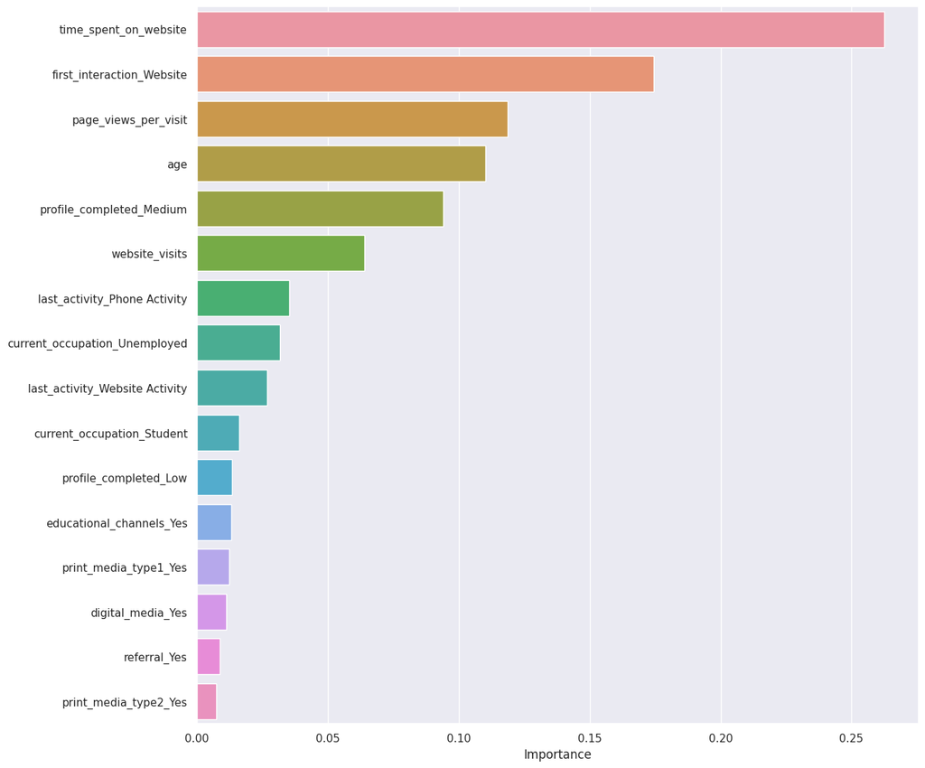

```python
importances = rf_estimator.feature_importances_

columns = x.columns

importance_df = pd.DataFrame(importances, index = columns, columns = ['Importance']).sort_values(by = 'Importance', ascending = False)

plt.figure(figsize = (13, 13))

sns.barplot(x=importance_df.Importance, y=importance_df.index);
```

### **Tuning the Random Forest classifier**

```python
# Choose the type of classifier
rf_estimator_tuned = RandomForestClassifier(class_weight = {0: 0.3, 1: 0.7}, random_state = 1)

# Grid of parameters to choose from
params_rf = {
        "n_estimators": [100, 250, 500],
        "min_samples_leaf": np.arange(1, 4, 1),
        "max_features": [0.7, 0.9, 'auto'],
}


# Type of scoring used to compare parameter combinations - recall score for class 1
scorer = metrics.make_scorer(recall_score, pos_label = 1)

# Run the grid search
grid_obj = GridSearchCV(rf_estimator_tuned, params_rf, scoring = scorer, cv = 5)

grid_obj = grid_obj.fit(x_train, y_train)

# Set the classifier to the best combination of parameters
rf_estimator_tuned = grid_obj.best_estimator_
```

```python
rf_estimator_tuned.fit(x_train, y_train)
```

```
RandomForestClassifier(class_weight={0: 0.3, 1: 0.7}, max_features='auto',
                       min_samples_leaf=3, random_state=1)
```

```
              precision    recall  f1-score   support

           0       0.97      0.93      0.95      2264
           1       0.85      0.94      0.89       964

    accuracy                           0.93      3228
   macro avg       0.91      0.93      0.92      3228
weighted avg       0.94      0.93      0.93      3228
```

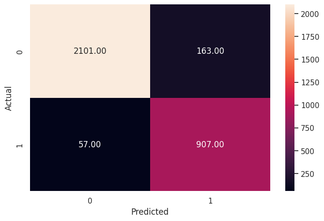

```python
# Checking performance on the training data
y_pred_train_rf_tuned = rf_estimator_tuned.predict(x_train)

metrics_score(y_train, y_pred_train_rf_tuned)
```

```
              precision    recall  f1-score   support

           0       0.90      0.88      0.89       971
           1       0.74      0.78      0.76       413

    accuracy                           0.85      1384
   macro avg       0.82      0.83      0.83      1384
weighted avg       0.85      0.85      0.85      1384
```

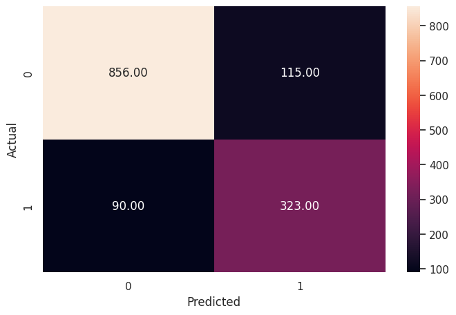

```python
# Checking performance on the test data
y_pred_test_rf_tuned = rf_estimator_tuned.predict(x_test)

metrics_score(y_test, y_pred_test_rf_tuned)
```

```python
rf_estimator_tuned_test = model_performance_classification(rf_estimator_tuned, x_test, y_test)
rf_estimator_tuned_test
```

|  | Precision | Recall | Accuracy |
| --- | --- | --- | --- |
| 0 | 0.821153 | 0.831824 | 0.851879 |

**Observations:**

- The tuned model **shows a good performance on the test dataset.**
- **The recall for class 1 has improved with a small decrease in precision**.
- **This model is the best-performing one among all the models so far,** and is giving us good precision and recall scores on the test dataset.

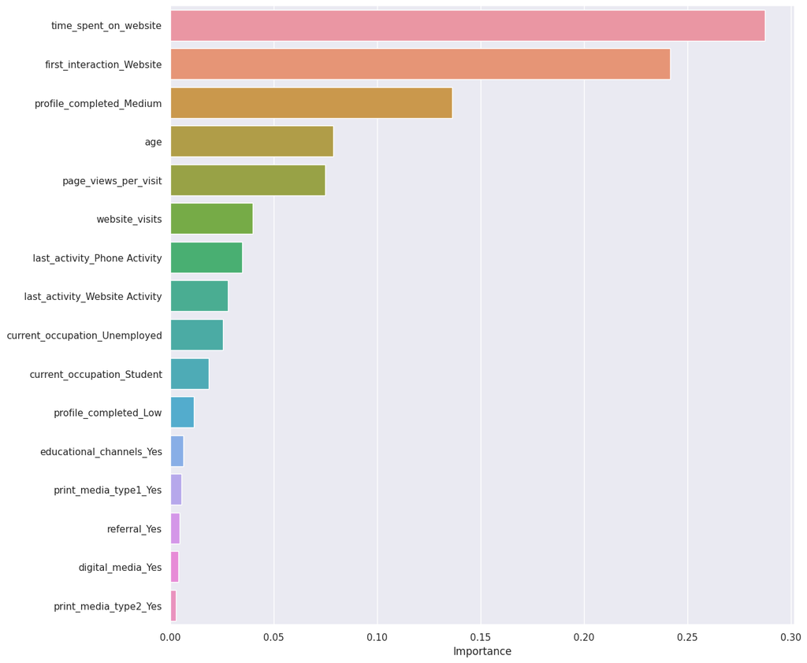

```python
# Plotting feature importance
importances = rf_estimator_tuned.feature_importances_

columns = x.columns

importance_df = pd.DataFrame(importances, index = columns, columns = ['Importance']).sort_values(by = 'Importance', ascending = False)

plt.figure(figsize = (13, 13))

sns.barplot(x=importance_df.Importance, y=importance_df.index);
```

**Observations:**

- **The feature importance plot for the base model and tuned model are quite similar.** The model seems to suggest that `time spent on website`, `first interaction website`, `profile completed medium`,`Age`, and `page views per visit` are the **most important features**.

## **Recommendations**

- We saw that **higher time spent on the website is one of the most important features for converting leads to paid customers.** Extraalearn should ensure more resources are available on website than phone app
- **Professionals and older customers are more likey to convert to paid customers.** The company should make sure that all provide resources that would benefit professionals to upskills.
- As observed earlier,customers less than 18 years are not likely to convert to paid customers. Affordable or free programs for younger customers should be provided to better attract these target customers.
- Also, the last interaction via email activity was higher than interaction via phone or websity activity. A higher percentage of the customers preferred to seek detail about the program via email, hence Extraalearn should focus on sharing information with leads via email
- There was little impact on other channels such as print media, digital media, referrals, etc on conversion to paid customer. Hence Extraalearn should reduce the amount of resources allocated there. Though, these channels hadlittle or no effect on conversion of leads to paid customers, education channel seem to provide the highest lead with higher conversion to paid customers. Extraalearn should focus on providing more education products.